# sample

```python
import pandas as pd

df = pd.read_spss("./data/Pair-15.sav")
```

```python
df.head()
```

|  | id | x1 | x2 | x3 | x4 | x5 | x6 | x7 | x8 | x9 | ... | x14 | x15 | x16 | x17 | x18 | x19 | x20 | x21 | x22 | x23 |
| --- | --- | --- | --- | --- | --- | --- | --- | --- | --- | --- | --- | --- | --- | --- | --- | --- | --- | --- | --- | --- | --- |
| 0 | 21.0 | 1.0 | 0.0 | 0.0 | 1.0 | 0.0 | 5.2 | 3.8 | 7.1 | 5.2 | ... | 7.1 | 4.6 | 3.3 | 4.9 | 3.3 | 5.4 | 5.5 | 7.0 | 50.1 | 0.0 |
| 1 | 22.0 | 3.0 | 1.0 | 1.0 | 1.0 | 1.0 | 9.6 | 5.7 | 6.8 | 5.9 | ... | 6.4 | 6.5 | 4.3 | 3.0 | 4.3 | 9.9 | 9.6 | 9.9 | 70.1 | 1.0 |
| 2 | 23.0 | 2.0 | 0.0 | 0.0 | 0.0 | 1.0 | 8.6 | 3.6 | 7.4 | 5.1 | ... | 6.7 | 6.0 | 4.8 | 3.4 | 4.0 | 7.0 | 7.1 | 8.1 | 60.1 | 0.0 |
| 3 | 24.0 | 3.0 | 0.0 | 1.0 | 1.0 | 1.0 | 9.3 | 2.4 | 2.6 | 7.2 | ... | 6.4 | 4.2 | 6.7 | 4.4 | 4.5 | 8.6 | 8.1 | 8.0 | 65.1 | 1.0 |
| 4 | 25.0 | 1.0 | 0.0 | 0.0 | 1.0 | 0.0 | 6.0 | 4.1 | 5.3 | 4.7 | ... | 6.5 | 3.9 | 4.7 | 5.3 | 4.0 | 4.8 | 4.9 | 5.5 | 55.1 | 0.0 |

5 rows × 24 columns

# Renaming Columns

```python
df.columns = ['id', 'Customer_Type', 'Industry_Type', 'Firm_Size', 'Region', 'Distribution_System',
              'Product_Quality', 'E_Commerce', 'Technical_Support', 'Complaint_Resolution',
              'Advertising', 'Product_Line', 'Salesforce_Image', 'Competitive_Pricing',
              'Warranty_Claims', 'New_Products', 'Ordering_Billing', 'Price_Flexibility',
              'Delivery_Speed', 'Satisfaction', 'Likelihood_Recommend',
              'Likelihood_Future_Purchase', 'Current_Purchase_Level', 'Consider_Strategic_Alliance']

df.head()
```

|  | id | Customer_Type | Industry_Type | Firm_Size | Region | Distribution_System | Product_Quality | E_Commerce | Technical_Support | Complaint_Resolution | ... | Warranty_Claims | New_Products | Ordering_Billing | Price_Flexibility | Delivery_Speed | Satisfaction | Likelihood_Recommend | Likelihood_Future_Purchase | Current_Purchase_Level | Consider_Strategic_Alliance |
| --- | --- | --- | --- | --- | --- | --- | --- | --- | --- | --- | --- | --- | --- | --- | --- | --- | --- | --- | --- | --- | --- |
| 0 | 21.0 | 1.0 | 0.0 | 0.0 | 1.0 | 0.0 | 5.2 | 3.8 | 7.1 | 5.2 | ... | 7.1 | 4.6 | 3.3 | 4.9 | 3.3 | 5.4 | 5.5 | 7.0 | 50.1 | 0.0 |
| 1 | 22.0 | 3.0 | 1.0 | 1.0 | 1.0 | 1.0 | 9.6 | 5.7 | 6.8 | 5.9 | ... | 6.4 | 6.5 | 4.3 | 3.0 | 4.3 | 9.9 | 9.6 | 9.9 | 70.1 | 1.0 |
| 2 | 23.0 | 2.0 | 0.0 | 0.0 | 0.0 | 1.0 | 8.6 | 3.6 | 7.4 | 5.1 | ... | 6.7 | 6.0 | 4.8 | 3.4 | 4.0 | 7.0 | 7.1 | 8.1 | 60.1 | 0.0 |
| 3 | 24.0 | 3.0 | 0.0 | 1.0 | 1.0 | 1.0 | 9.3 | 2.4 | 2.6 | 7.2 | ... | 6.4 | 4.2 | 6.7 | 4.4 | 4.5 | 8.6 | 8.1 | 8.0 | 65.1 | 1.0 |
| 4 | 25.0 | 1.0 | 0.0 | 0.0 | 1.0 | 0.0 | 6.0 | 4.1 | 5.3 | 4.7 | ... | 6.5 | 3.9 | 4.7 | 5.3 | 4.0 | 4.8 | 4.9 | 5.5 | 55.1 | 0.0 |

5 rows × 24 columns

## 1. Correlation Analysis

Hypothesis: There is a significant correlation between customer satisfaction (X19) and likelihood to recommend HBAT (X20).

Variables:

- X19: Customer Satisfaction (interval)
- X20: Likelihood of Recommendation (interval)

```
Correlation coefficient: 0.8024131939585863
P-value: 2.4472100974100128e-12
```

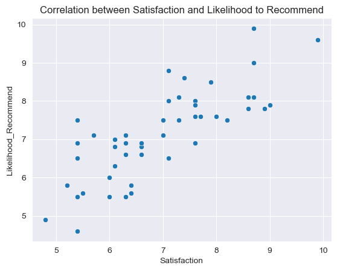

```python
import seaborn as sns
import matplotlib.pyplot as plt
from scipy.stats import pearsonr

# Calculate correlation
corr, p_value = pearsonr(df['Satisfaction'], df['Likelihood_Recommend'])

print(f"Correlation coefficient: {corr}")
print(f"P-value: {p_value}")

# Plot correlation
sns.scatterplot(x='Satisfaction', y='Likelihood_Recommend', data=df)
plt.title('Correlation between Satisfaction and Likelihood to Recommend')
plt.show()
```

## 2. Cross-tab (Chi-square) Analysis

Hypothesis: There is an association between industry type (X2) and the type of distribution system used (X5).

Variables:

- x2: Industry Type (nominal)
- x5: Distribution System (nominal)

```python
from scipy.stats import chi2_contingency

# Create contingency table
contingency_table = pd.crosstab(df['Industry_Type'], df['Distribution_System'])

# Perform Chi-square test
chi2, p, dof, expected = chi2_contingency(contingency_table)

print(f"Chi-square statistic: {chi2}")
print(f"P-value: {p}")
print(f"Degrees of freedom: {dof}")
print("Expected frequencies:")
print(expected)
```

```
Chi-square statistic: 0.08680555555555555
P-value: 0.7682782035458339
Degrees of freedom: 1
Expected frequencies:
[[16.  9.]
 [16.  9.]]
```

## 3. Independent Samples t-test

**Hypothesis:** The average likelihood of future purchase differs between customers who consider a strategic alliance/partnership with HBAT and those who do not.

- **Null Hypothesis (H0):** There is no significant difference in the average likelihood of future purchase between customers considering a strategic alliance/partnership with HBAT and those who do not.
  - μ1 = μ2 (where μ1 is the population mean likelihood of future purchase for customers considering a strategic alliance/partnership, and μ2 is the population mean likelihood of future purchase for customers not considering a strategic alliance/partnership)
- **Alternative Hypothesis (H1):** There is a significant difference in the average likelihood of future purchase between the two groups.
  - μ1 ≠ μ2 (the population means are not equal)

### Variables for Independent Samples t-test

- **Group 1 (Consider Strategic Alliance/Partnership):**
  - **Grouping Variable:** Consider_Strategic_Alliance (Yes)
- **Group 2 (Do Not Consider Strategic Alliance/Partnership):**
  - **Grouping Variable:** Consider_Strategic_Alliance (No)
- **Dependent Variable:** Likelihood of Future Purchase

```python
from scipy.stats import ttest_ind

# Separate data into two groups
consider_alliance = df[df['Consider_Strategic_Alliance'] == 1]['Likelihood_Future_Purchase']
not_consider_alliance = df[df['Consider_Strategic_Alliance'] == 0]['Likelihood_Future_Purchase']

# Perform t-test
t_stat, p_value = ttest_ind(consider_alliance, not_consider_alliance)

print(f"T-statistic: {t_stat}")
print(f"P-value: {p_value}")
```

```
T-statistic: 6.897329167742462
P-value: 1.056565423140144e-08
```

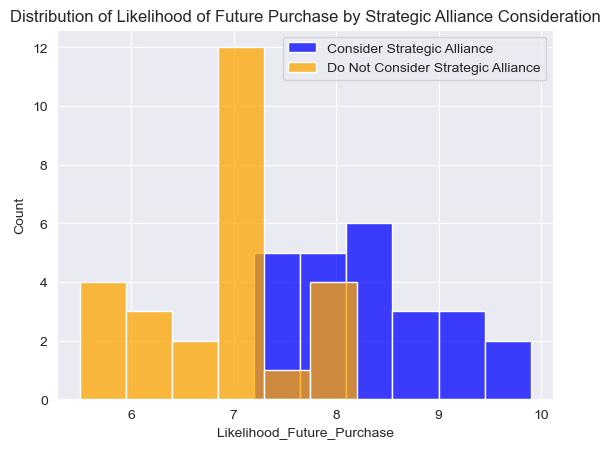

```python
# Plot the distribution of likelihood of future purchase for the two groups
sns.histplot(consider_alliance, color='blue', label='Consider Strategic Alliance')
sns.histplot(not_consider_alliance, color='orange', label='Do Not Consider Strategic Alliance')
plt.title('Distribution of Likelihood of Future Purchase by Strategic Alliance Consideration')
plt.legend()
plt.show()
```

```python
# Calculate the means for the two groups
mean_consider_alliance = consider_alliance.mean()
mean_not_consider_alliance = not_consider_alliance.mean()

print(f"Mean Likelihood of Future Purchase (Consider Strategic Alliance): {mean_consider_alliance}")
print(f"Mean Likelihood of Future Purchase (Do Not Consider Strategic Alliance): {mean_not_consider_alliance}")
```

```
Mean Likelihood of Future Purchase (Consider Strategic Alliance): 8.354166666666666
Mean Likelihood of Future Purchase (Do Not Consider Strategic Alliance): 6.911538461538461
```

#### Interpretation of Results

With such a small p-value (much smaller than the typical significance level of 0.05), we reject the null hypothesis. Therefore, we can conclude that there is a significant difference in the average likelihood of future purchase between customers who consider a strategic alliance/partnership with HBAT and those who do not. The mean likelihood of future purchase for customers considering a strategic alliance/partnership is significantly different from the mean likelihood for customers who do not consider such an alliance.

## 4. ANOVA

Hypothesis: Customer satisfaction (X19) differs across different customer size categories (X3).

Variables:

```python
import statsmodels.api as sm
from statsmodels.formula.api import ols
from statsmodels.stats.anova import anova_lm

# Perform ANOVA
model = ols('Satisfaction ~ C(Firm_Size)', data=df).fit()
anova_table = anova_lm(model)

print(anova_table)
```

```
                df   sum_sq   mean_sq         F    PR(>F)
C(Firm_Size)   1.0   7.9520  7.952000  5.885266  0.019076
Residual      48.0  64.8562  1.351171       NaN       NaN
```

## 5. Bivariate Linear Regression

Hypothesis: Customer satisfaction (X19) can be predicted by product quality (X6).

```python
import statsmodels.api as sm

# Define the dependent and independent variables
X = df[['Product_Quality']]
y = df['Satisfaction']

# Add a constant to the independent variable matrix
X = sm.add_constant(X)

# Fit the regression model
model = sm.OLS(y, X).fit()

print(model.summary())
```

```
                            OLS Regression Results
==============================================================================
Dep. Variable:           Satisfaction   R-squared:                       0.216
Model:                            OLS   Adj. R-squared:                  0.200
Method:                 Least Squares   F-statistic:                     13.24
Date:                Tue, 21 May 2024   Prob (F-statistic):           0.000668
Time:                        18:29:51   Log-Likelihood:                -74.251
No. Observations:                  50   AIC:                             152.5
Df Residuals:                      48   BIC:                             156.3
Df Model:                           1
Covariance Type:            nonrobust
===================================================================================
                      coef    std err          t      P>|t|      [0.025      0.975]
-----------------------------------------------------------------------------------
const               3.7835      0.872      4.340      0.000       2.031       5.536
Product_Quality     0.4018      0.110      3.639      0.001       0.180       0.624
==============================================================================
Omnibus:                        3.894   Durbin-Watson:                   2.015
Prob(Omnibus):                  0.143   Jarque-Bera (JB):                2.419
Skew:                           0.331   Prob(JB):                        0.298
Kurtosis:                       2.149   Cond. No.                         45.3
==============================================================================

Notes:
[1] Standard Errors assume that the covariance matrix of the errors is correctly specified.
```

### Bivariate Linear Regression Results Interpretation

The output provides insights into the relationship between customer satisfaction and product quality based on a bivariate linear regression analysis.

- **R-squared**: The coefficient of determination (R-squared) is 0.216, indicating that approximately 21.6% of the variability in customer satisfaction can be explained by product quality.
- **Coefficients**:
  - **Intercept (const)**: The baseline satisfaction score when product quality is zero is approximately 3.7835.
  - **Product Quality**: The coefficient for product quality is 0.4018, indicating that for each unit increase in product quality, there is an associated increase of approximately 0.4018 units in customer satisfaction.
- **Significance**:
  - **p-value for Product Quality**: The p-value associated with the coefficient for product quality is 0.001, which is less than the conventional significance level of 0.05. This suggests that product quality is a significant predictor of customer satisfaction.
- **Model Fit**:
  - **F-statistic**: The F-statistic is 13.24 with a corresponding p-value of 0.000668, indicating that the regression model as a whole is statistically significant in explaining the variability in customer satisfaction.
- **Adjusted R-squared**: The adjusted R-squared value is 0.200, which adjusts the R-squared value based on the number of predictors in the model. It provides a more accurate assessment of the model's goodness of fit when compared to the ordinary R-squared.
- **Other Statistics**:
  - **Omnibus, Durbin-Watson, Jarque-Bera, Skew, Kurtosis**: These statistics provide information about the residuals, including their normality and autocorrelation properties.

Overall, the analysis suggests that product quality significantly influences customer satisfaction, with higher product quality associated with higher levels of satisfaction. However, it's important to consider other factors that may also impact customer satisfaction beyond product quality.

## 6. Multiple Linear Regression

Hypothesis: Customer satisfaction can be predicted by product quality, technical support, and competitive pricing.

```python
import statsmodels.api as sm

# Define dependent and independent variables
X = df[['Product_Quality', 'Technical_Support', 'Competitive_Pricing']]
y = df['Satisfaction']

# Add a constant to the independent variables matrix
X = sm.add_constant(X)

# Fit the regression model
model = sm.OLS(y, X).fit()

# Print the summary
print(model.summary())
```

```
                            OLS Regression Results
==============================================================================
Dep. Variable:           Satisfaction   R-squared:                       0.227
Model:                            OLS   Adj. R-squared:                  0.177
Method:                 Least Squares   F-statistic:                     4.512
Date:                Tue, 21 May 2024   Prob (F-statistic):            0.00741
Time:                        18:29:51   Log-Likelihood:                -73.893
No. Observations:                  50   AIC:                             155.8
Df Residuals:                      46   BIC:                             163.4
Df Model:                           3
Covariance Type:            nonrobust
=======================================================================================
                          coef    std err          t      P>|t|      [0.025      0.975]
---------------------------------------------------------------------------------------
const                   3.0372      1.707      1.779      0.082      -0.400       6.474
Product_Quality         0.4360      0.122      3.575      0.001       0.191       0.681
Technical_Support      -0.0114      0.110     -0.104      0.918      -0.233       0.210
Competitive_Pricing     0.0806      0.112      0.719      0.476      -0.145       0.306
==============================================================================
Omnibus:                        2.814   Durbin-Watson:                   1.983
Prob(Omnibus):                  0.245   Jarque-Bera (JB):                2.161
Skew:                           0.356   Prob(JB):                        0.339
Kurtosis:                       2.271   Cond. No.                         129.
==============================================================================

Notes:
[1] Standard Errors assume that the covariance matrix of the errors is correctly specified.
```

### Multiple Linear Regression Results Interpretation

The output provides insights into the relationship between customer satisfaction and multiple predictors (product quality, technical support, and competitive pricing) based on a multiple linear regression analysis.

- **R-squared**: The coefficient of determination (R-squared) is 0.227, indicating that approximately 22.7% of the variability in customer satisfaction can be explained by the combination of product quality, technical support, and competitive pricing.
- **Adjusted R-squared**: The adjusted R-squared value is 0.177, which adjusts the R-squared value based on the number of predictors in the model. It provides a more accurate assessment of the model's goodness of fit when compared to the ordinary R-squared.
- **Coefficients**:
  - **Intercept (const)**: The baseline satisfaction score when all predictors are zero is approximately 3.0372.
  - **Product Quality**: The coefficient for product quality is 0.4360, indicating that for each unit increase in product quality, there is an associated increase of approximately 0.4360 units in customer satisfaction.
  - **Technical Support**: The coefficient for technical support is -0.0114, but its p-value is not significant (0.918), suggesting that technical support may not have a significant impact on customer satisfaction.
  - **Competitive Pricing**: The coefficient for competitive pricing is 0.0806, but its p-value is also not significant (0.476), suggesting that competitive pricing may not have a significant impact on customer satisfaction.
- **Significance**:
  - The overall model is statistically significant, with an F-statistic of 4.512 and a corresponding p-value of 0.00741.
- **Other Statistics**:
  - **Omnibus, Durbin-Watson, Jarque-Bera, Skew, Kurtosis**: These statistics provide information about the residuals, including their normality and autocorrelation properties.

Overall, the analysis suggests that product quality significantly influences customer satisfaction, while technical support and competitive pricing may not have significant effects in this model. However, it's important to consider other factors that may also impact customer satisfaction beyond the variables included in this analysis.